# STA713 함수추정방법 기말고사

황소연

2020 6 22

# 유의사항

##### * 시험범위는 ISLR 1 ~ 7장, 9장입니다. 시험범위 이외의 방법론은 사용불가입니다.

##### * 시드가 주어진 문항에 대해 반드시 처음 코드를 `set.seed(1)`로 실행하여 답하시기 바랍니다.

##### * 1, 2번 문제에서 주어진 함수이외의 R-패키지의 함수를 사용하지 마시기 바랍니다. (내장함수만 사용할 것)

##### * 4, 5번 문제의 데이터는 출제자가 일부를 가지고 있습니다(시험 데이터). 모형의 정확도 평가를 위해 시험 데이터에 대해 예측이 가능한 객체 형태로 답을 하시기 바랍니다.

##### * 수강생들끼리 상의하여 문제를 푸는 것을 금합니다. (답안 확인시 발각되면 0점)

##### * 제출기한 : 2020년 6월 22일 17:00시

##### * Rmd파일을 html로 변환 후 변환된 파일과 Rmd파일을 압축하여 kjg612@korea.ac.kr로 제출해주시기 바랍니다.

##### * 이메일을 보낼 시 본인 참조하시기 바랍니다. (제출 시간 확인용)

##### * 이메일 제목 : STA713_Final_학번

##### * Rmd파일과 변환된 파일 제목 : STA713_Final_학번

##### * 시험 문제와 관련한 문의사항은 kjg612@korea.ac.kr 로 보내주시면 됩니다.

### Q1.

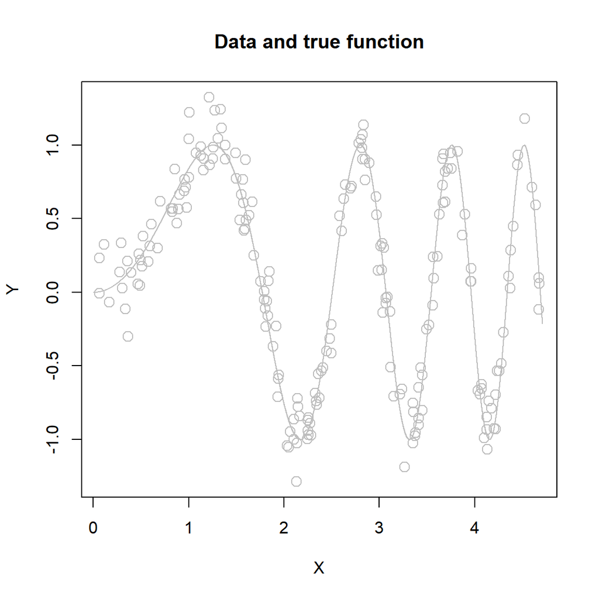

```r
set.seed(1)
n = 200
X = runif(n, 0, 1.5 * pi)
f = sin(X^2)
Y = f + rnorm(n, sd = 0.15)
plot(X, Y, main = "Data and true function", col = "grey", cex = 1.4)
grid_x = seq(0, 1.5 * pi, length = 10000)
lines(grid_x, sin(grid_x^2), col = "grey")
```

2. R-패키지 FNN 의 내장함수 `knnx.index` 를 이용하여 $x = 3$ 에서 $K = 10$ 일때, 이웃을 구하시오 (`knnx.index` 함수의 인자는 data, query, K 로 각각 이웃의 후보, 기준값, 이웃의 개수로 이해할 수 있다. 출력값으로 query 를 기준으로 $K$ 개 이웃에 해당하는 data 의 인덱스를 원소로 하는 행렬을 반환한다.)

```r
df = cbind(X, Y)

library(FNN)
idx = knnx.index(X, 3, 10) ; idx
```

```
##      [,1] [,2] [,3] [,4] [,5] [,6] [,7] [,8] [,9] [,10]
## [1,]  105  120   93  134  171    9  177   42   65    23
```

```r
df[idx, ] # 10-nearest neighbors at x = 3
```

```
##              X           Y
##  [1,] 2.985267  0.14797381
##  [2,] 3.016405  0.31362395
##  [3,] 3.026712  0.15098078
##  [4,] 3.029102  0.33231794
##  [5,] 2.970757  0.52529358
##  [6,] 2.964630  0.65140606
##  [7,] 3.036267 -0.13895590
##  [8,] 3.049199  0.30330650
##  [9,] 3.067155 -0.07554803
## [10,] 3.070940 -0.03808308
```

3. 데이터의 산점도를 검은 점으로 그린 후, 문항 (b) 에서 구한 이웃을 빨간 점으로 표시하시오. $x = 3$ 에서 KNN 회귀값을 예측하고 수평선으로 그리시오.

```r
# 예측한 KNN 회귀값
print(paste("fitted value at x = 3: ", mean(df[idx, 2])))
```

```
## [1] "fitted value at x = 3:  0.217231559751172"
```

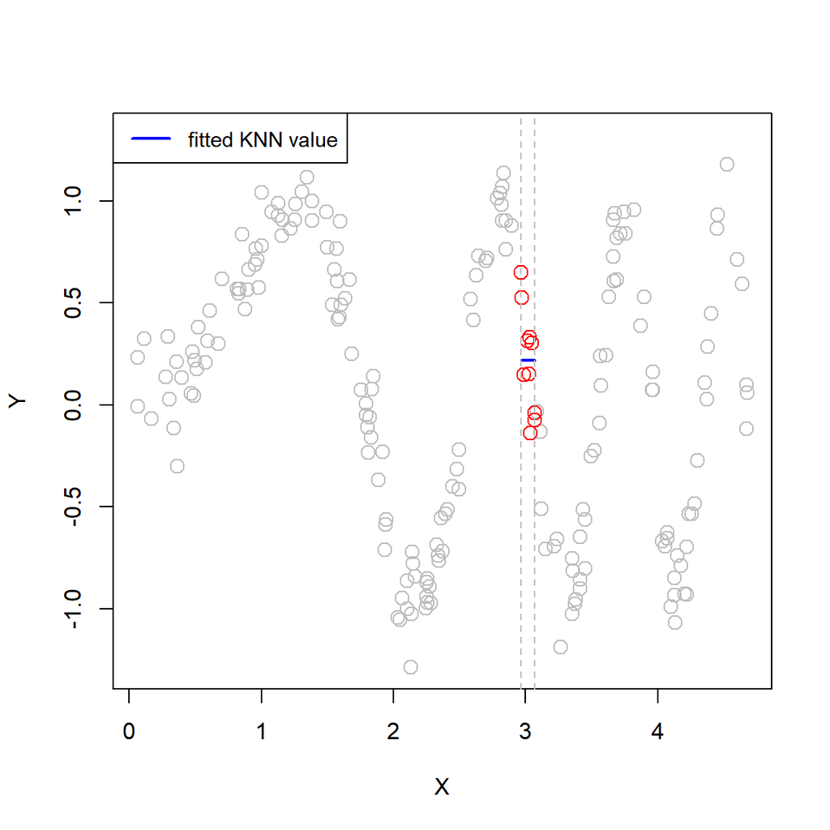

```r
plot(X, Y, col = "grey", cex = 1.4)
points(df[idx, 1], df[idx, 2], col = "red", cex = 1.4)
lines(sort(df[idx, 1]), rep(mean(df[idx, 2]), length(df[idx, 2])),
      lwd = 2, col = "blue")
abline(v = c(min(sort(df[idx, 1])), max(sort(df[idx, 1]))), lty = 2, col = "grey")
legend("topleft", legend = c("fitted KNN value"), lty = 1, lwd = 2, col = "blue",
       cex = 0.9)
```

4. 함수 `knnx.index` 을 이용하여 $f$ 에 대한 KKN 추정치를 구하고 데이터 산점도 위에 그리시오. (단, $K = 5$ 로 설정하시오)

```r
grid_x = seq(min(df[, 1]), max(df[, 1]), length = 10000)
idx_d = knnx.index(sort(df[, 1]), grid_x, 5)
y_ordered = df[order(df[, 1]), 2]
yhat = c()
for (i in 1:nrow(idx_d))
{
   pred = mean(y_ordered[idx_d[i, ]])
   yhat[i] = pred
}
length(yhat)
```

```
## [1] 10000
```

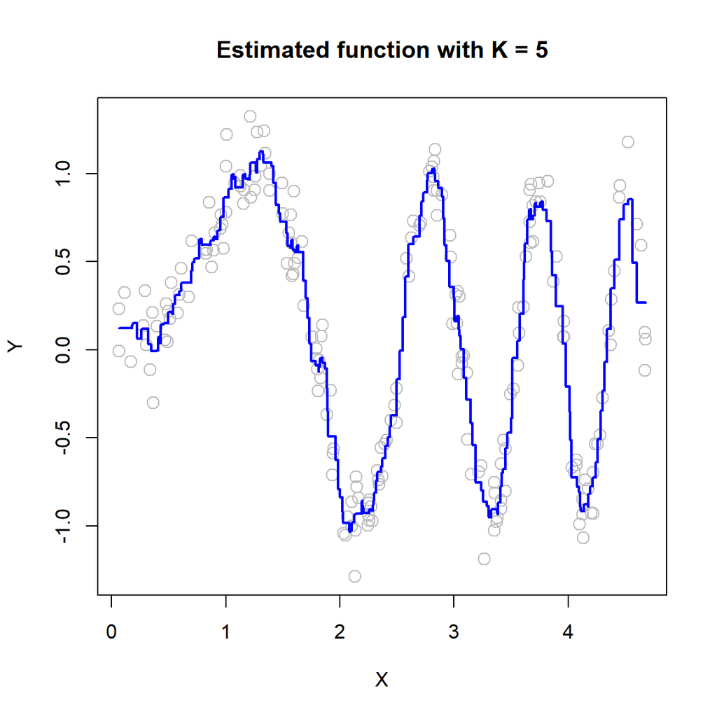

```r
plot(X, Y, col = "grey", cex = 1.4, main = "Estimated function with K = 5")
lines(grid_x, yhat, col = "blue", lwd = 2)
```

6. 문항 (d) 를 $K = 1, 5, 10, 30, 100, 200$ 에 대해 반복하시오.

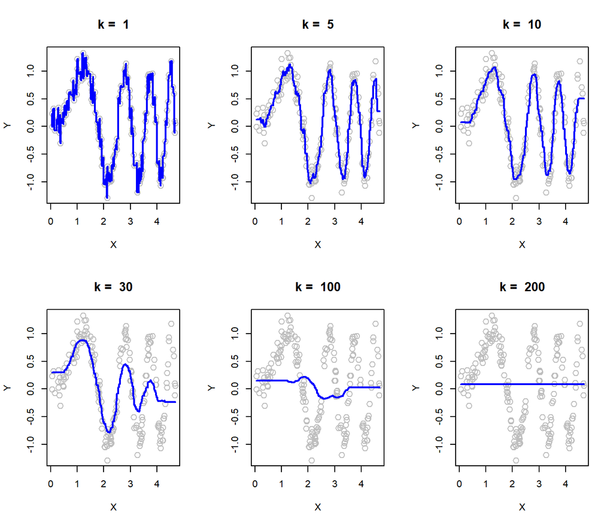

```r
par(mfrow = c(2, 3))
K = c(1, 5, 10, 30, 100, 200)
for (k in K)
{
   grid_x = seq(min(df[, 1]), max(df[, 1]), length = 10000)
   idx_d = knnx.index(sort(df[, 1]), grid_x, k)
   y_ordered = df[order(df[, 1]), 2]

   yhat = c()
   for (i in 1:nrow(idx_d))
   {
      pred = mean(y_ordered[idx_d[i, ]])
      yhat[i] = pred
   }

   plot(X, Y, main = paste("k = ", k), cex = 1.4, col = "grey", cex.main = 1.3)
   lines(grid_x, yhat, col = "blue", lwd = 2)
}
```

7. $K = 1, 2, \ldots, 40$ 에 대하여 10-겹 교차검증를 수행하고 최적의 K 를 제시하시오. (R-패키지 caret 의 `createFolds(x, k = 10, list = TRUE, returnTrain = TRUE)` 를 이용하여 겹을 생성하시오.)

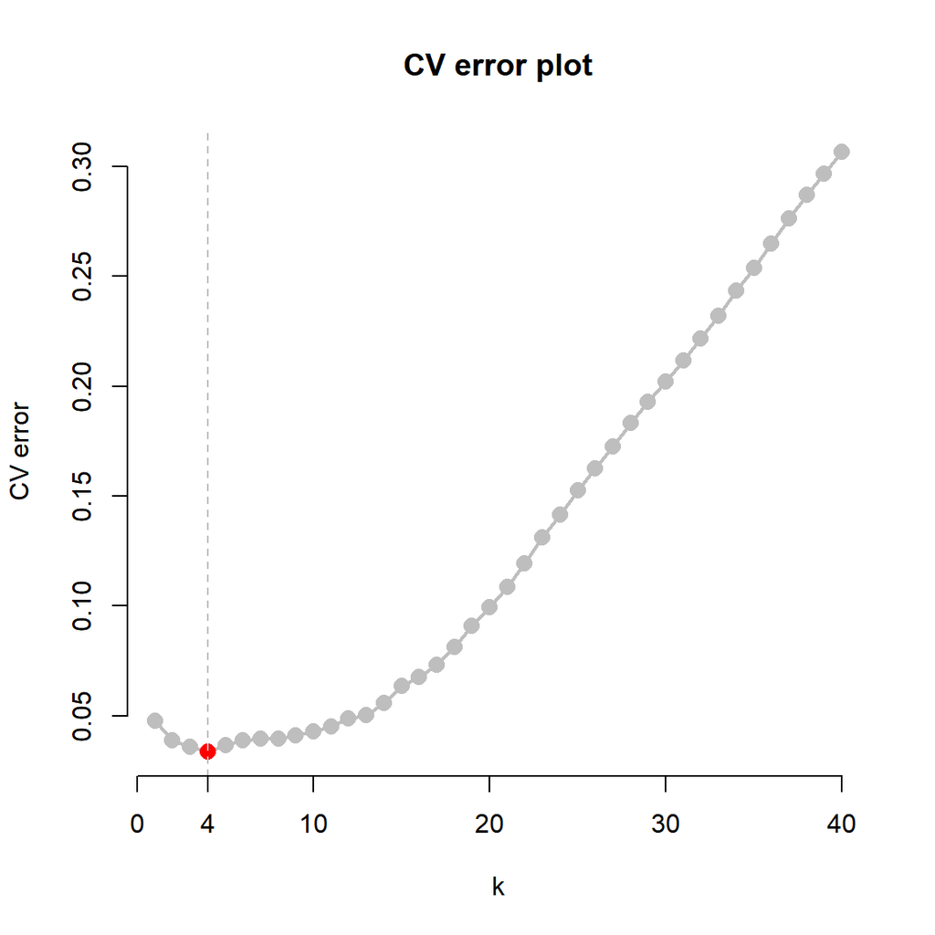

```r
par(mfrow = c(1, 1))
# set folds
set.seed(1)
library(caret)
fold = createFolds(X, k = 10, list = TRUE, returnTrain = TRUE)

# cv function
df_origin = df
K = c(1:40)
mse_list_k = c()

# k = complexity
for (k in K)
{
   mse_fold = c()
   for (i in 1:10)
   {
      # split into validation & training
      df_train = df_origin[unlist(fold[i]), ]
      df_val = df_origin[-unlist(fold[i]), ]

      # valid neighbors
      idx = knnx.index(df_train[, 1], df_val[, 1], k)

      # yhat
      fitted = c()
      for (l in 1:nrow(df_val))
      {
         pred = mean(df_train[idx[l, ], 2])
         fitted[l] = pred
      }

      # mse at i-th fold
      mse_fold[i] = mean((df_val[, 2] - fitted)^2)
   }
   mse_list_k[k] = mean(mse_fold)
}

plot(c(1:40), mse_list_k, main = "CV error plot",
     xlab = "k", ylab = "CV error", type = "o", cex = 1.4, col = "grey",
     pch = 16, lwd = 2, axes = F)
points(which.min(mse_list_k), mse_list_k[which.min(mse_list_k)],
       col = "red", pch = 16, cex = 1.4)
abline(v = 4, lty = 2, col = "grey")
abline(h = )
ticks = c(0, 4, 10, 20, 30, 40)
axis(side = 1, at = ticks)
axis(side = 2)
```

```r
# 즉, 최적의 k는 4
```

8. 문항 (g) 에서 구한 최적의 K 에 대해 $f$ 에 대한 KKN 추정치를 데이터 산점도 위에 그리시오.

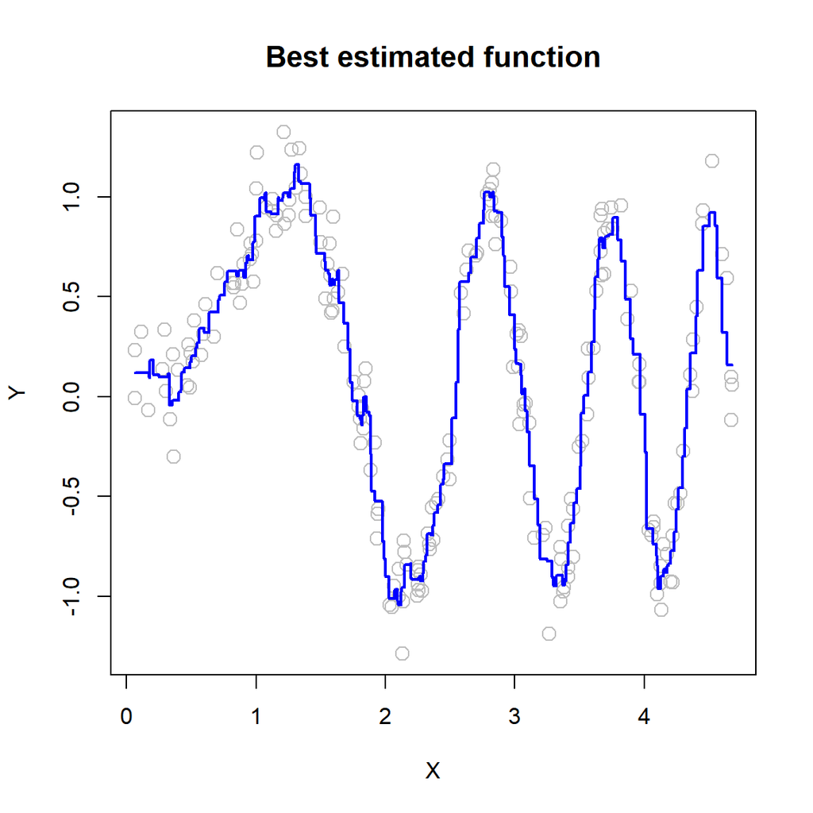

```r
grid_x = seq(min(df[, 1]), max(df[, 1]), length = 10000)
idx_d = knnx.index(sort(df[, 1]), grid_x, 4)  # k = 4
y_ordered = df[order(df[, 1]), 2]
yhat = c()
for (i in 1:nrow(idx_d))
{
   pred = mean(y_ordered[idx_d[i, ]])
   yhat[i] = pred
}

plot(X, Y, col = "grey", cex = 1.4, main = "Best estimated function",
     cex.main = 1.3)
lines(grid_x, yhat, col = "blue", lwd = 2)
```

### Q2.

로지스틱 회귀모형을 이용하여 Smarket 데이터의 범주형 변수 Direction 의 클래스를 분류하는 문제를 고려하자.

1. R-패키지 ISLR 의 Smarket 데이터로부터 Lag1, Lag2, Lag3, Lag4, Lag5, Volume 을 예측변수로, Direction 을 반응변수로 하여 로지스틱 회귀모형으로 적합하시오. (이때, Up은 성공으로 간주한다.)

```r
library(ISLR)
str(Smarket)
```

```
## 'data.frame':    1250 obs. of  9 variables:
##  $ Year     : num  2001 2001 2001 2001 2001 ...
##  $ Lag1     : num  0.381 0.959 1.032 -0.623 0.614 ...
##  $ Lag2     : num  -0.192 0.381 0.959 1.032 -0.623 ...
##  $ Lag3     : num  -2.624 -0.192 0.381 0.959 1.032 ...
##  $ Lag4     : num  -1.055 -2.624 -0.192 0.381 0.959 ...
##  $ Lag5     : num  5.01 -1.055 -2.624 -0.192 0.381 ...
##  $ Volume   : num  1.19 1.3 1.41 1.28 1.21 ...
##  $ Today    : num  0.959 1.032 -0.623 0.614 0.213 ...
##  $ Direction: Factor w/ 2 levels "Down","Up": 2 2 1 2 2 2 1 2 2 2 ...
```

```r
lr_fit = glm(Direction ~ Lag1 + Lag2 + Lag3 + Lag4 + Lag5 + Volume,
             data = Smarket, family = binomial)
summary(lr_fit)
```

```
##
## Call:
## glm(formula = Direction ~ Lag1 + Lag2 + Lag3 + Lag4 + Lag5 +
##     Volume, family = binomial, data = Smarket)
##
## Deviance Residuals:
##    Min      1Q  Median      3Q     Max
## -1.446  -1.203   1.065   1.145   1.326
##
## Coefficients:
##              Estimate Std. Error z value Pr(>|z|)
## (Intercept) -0.126000   0.240736  -0.523    0.601
## Lag1        -0.073074   0.050167  -1.457    0.145
## Lag2        -0.042301   0.050086  -0.845    0.398
## Lag3         0.011085   0.049939   0.222    0.824
## Lag4         0.009359   0.049974   0.187    0.851
## Lag5         0.010313   0.049511   0.208    0.835
## Volume       0.135441   0.158360   0.855    0.392
##
## (Dispersion parameter for binomial family taken to be 1)
##
##     Null deviance: 1731.2  on 1249  degrees of freedom
## Residual deviance: 1727.6  on 1243  degrees of freedom
## AIC: 1741.6
##
## Number of Fisher Scoring iterations: 3
```

```r
contrasts(Smarket$Direction) # Up : success
```

```
##      Up
## Down  0
## Up    1
```

2. 문턱값(threshold)을 0.5 로 하여 혼동행렬(confusion matrix)을 구하시오.

```r
probs = predict(lr_fit, type = "response")
pred = ifelse(probs > 0.5, "Up", "Down")

# confusion matrix
table(pred, Smarket$Direction)
```

```
##
## pred   Down  Up
##   Down  145 141
##   Up    457 507
```

3. ROC 곡선을 그리시오. (문턱값은 `seq(0, 1, length.out = 1000)` 으로부터 생성하라.)

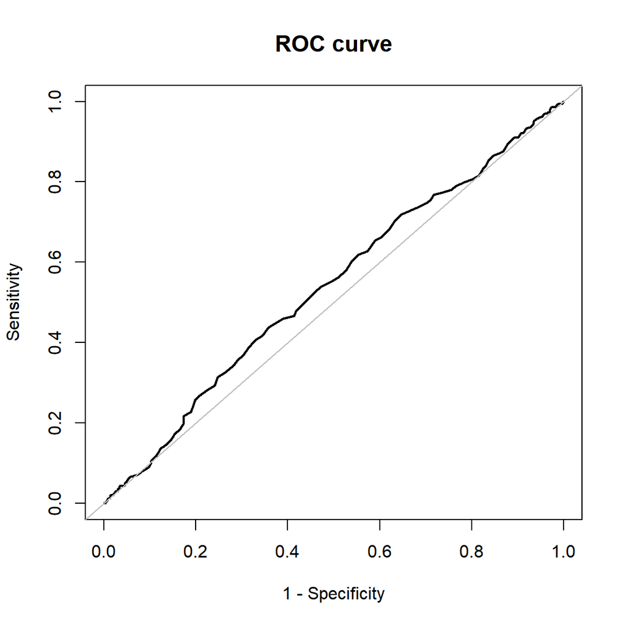

```r
threshold = seq(0, 1, length.out = 1000)
probs = predict(lr_fit, type = "response")
sens = c()
spec = c()
for (i in 1:length(threshold))
{
   cutoff = threshold[i]
   # confusino matrix
   pred = ifelse(probs > cutoff, "Up", "Down")
   tp = sum(pred == "Up" & Smarket$Direction == "Up")
   fp = sum(pred == "Up" & Smarket$Direction == "Down")
   fn = sum(pred == "Down" & Smarket$Direction == "Up")
   tn = sum(pred == "Down" & Smarket$Direction == "Down")
   # conf_mat = as.matrix(table(pred, Smarket$Direction))

   # sensitivity and specificity
   sens[i] = tp / (tp + fn)
   spec[i] = tn / (fp + tn)
}

plot(1-spec, sens, type = "l", lwd = 2, main = "ROC curve",
     xlab = "1 - Specificity", ylab = "Sensitivity", cex.main = 1.3)
abline(a = 0, b = 1.0, col = "grey")
```

### Q3.

$+1$ 또는 $-1$ 의 값을 갖는 범주형 확률 변수 $Y$ 와 2차원 연속형 확률 변수에 대해 다음 확률 모형을 가정하자.
$$\begin{align*}
X | Y = 1 \sim N(\mu_1, \Sigma), & \quad
X | Y = -1 \sim N(\mu_2, \Sigma) \\
P(Y = 1) = & P(Y = -1) = \frac{1}{2}
\end{align*}$$
이때, $\mu_1 = (7, 7)^T$, $\mu_2 = (3, 5)^T$, $\Sigma = \begin{bmatrix} 2 & 0 \\ 0 & 2 \end{bmatrix}$ 로 주어진다. data3 는 위 확률 모형에 의해 생성한 $200$ 개의 관측값들이다.

```r
data3 = read.csv("data3.csv")
str(data3)
```

```
## 'data.frame':    200 obs. of  3 variables:
##  $ x1: num  2.77 7 8.24 3.13 8.41 ...
##  $ x2: num  8.06 7.67 6.31 3.83 5 ...
##  $ y : int  -1 1 1 -1 1 1 1 1 -1 1 ...
```

1. $1$ 의 값을 갖는 $Y$ 의 관측치를 파란점으로 $-1$ 의 값을 갖는 $Y$ 의 관측치를 빨간점으로 그리시오.

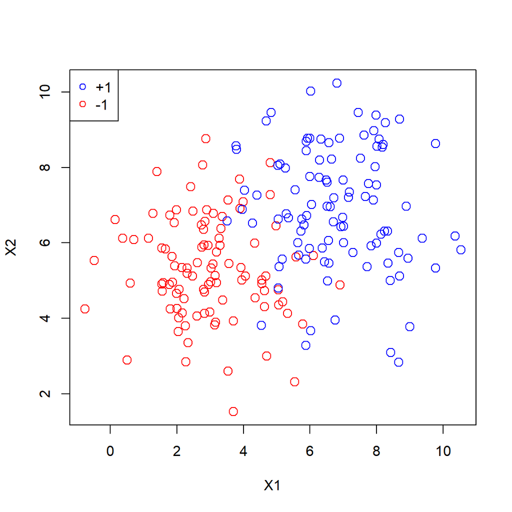

```r
red = data3[data3$y == -1, ]
blue = data3[data3$y == 1, ]
plot(red$x1, red$x2, col = "red",
     xlim = c(min(data3$x1), max(data3$x1)),
     ylim = c(min(data3$x2), max(data3$x2)),
     xlab = "X1", ylab = "X2", cex = 1.4)
points(blue$x1, blue$x2, col = "blue", cex = 1.4)
legend("topleft", legend = c("+1", "-1"), pch = c(1, 1),
       col = c("blue", "red"))
```

2. 위 확률모형을 이용하여 문항 (a) 에서 그린 플롯에 베이즈 결정경계를 검은 실선으로 그리시오.

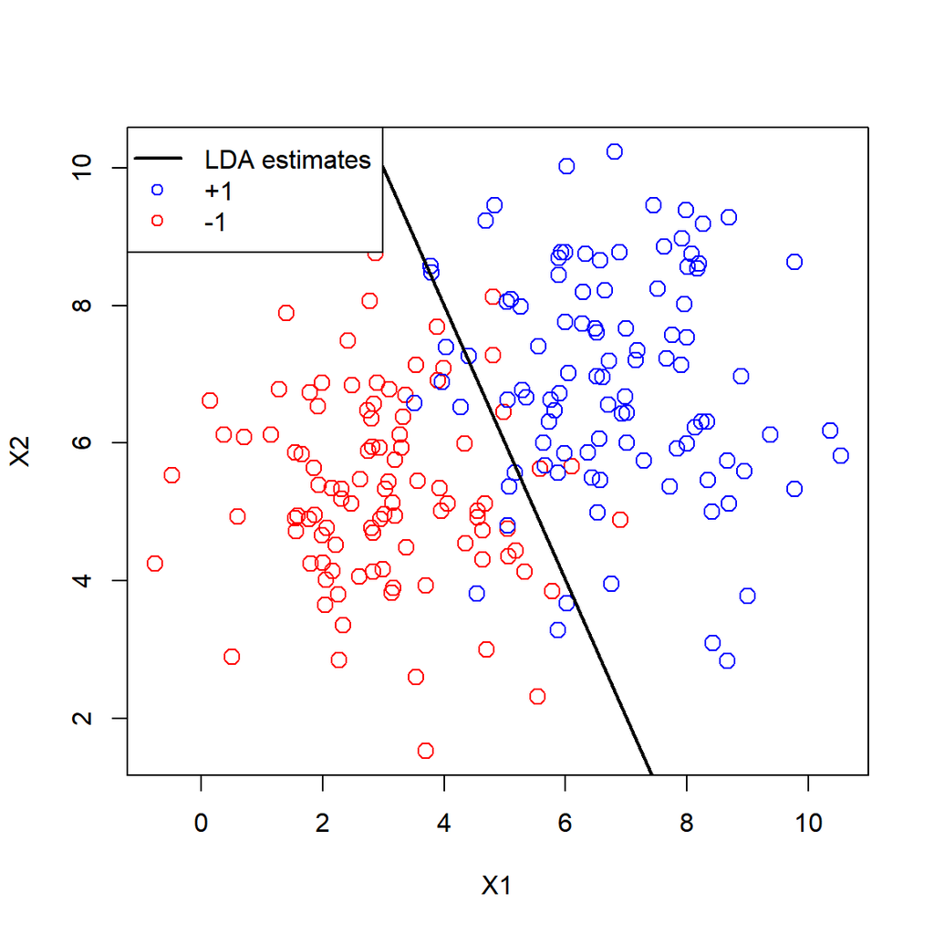

```r
# same covariance => LDA
mu1 = matrix(c(7, 7), 2, 1, byrow = T)
mu2 = matrix(c(3, 5), 2, 1, byrow = T)
sigma = matrix(c(2, 0, 0, 2), 2, 2, byrow = T)
pi1 = pi2 = 1/2

a1 = t(mu1) %*% solve(sigma)
b1 = - 1/2 * t(mu1) %*% solve(sigma) %*% mu1 + log(pi1)
a2 = t(mu2) %*% solve(sigma)
b2 = - 1/2 * t(mu2) %*% solve(sigma) %*% mu2 + log(pi2)

a = a1 - a2
b = b1 - b2

plot(red$x1, red$x2, col = "red",
     xlim = c(min(data3$x1), max(data3$x1)),
     ylim = c(min(data3$x2), max(data3$x2)),
     xlab = "X1", ylab = "X2", cex = 1.4)
points(blue$x1, blue$x2, col = "blue", cex = 1.4)
abline(a = -b, b = - a[1], lwd = 2)
legend("topleft", legend = c("LDA estimates", "+1", "-1"), pch = c(NA, 1, 1),
       lty = c(1, NA, NA), lwd = c(2, NA, NA),
       col = c("black", "blue", "red"))
```

### Q4.

data4 는 2 개의 연속형 변수와 $-1$ 또는 $+1$ 의 값을 갖는 범주형 변수의 관측값들을 포함한다. $x_1$ 과 $x_2$ 를 예측변수로 하여 반응변수 $y$ 를 예측하는 분류 모형을 만들고자 한다.

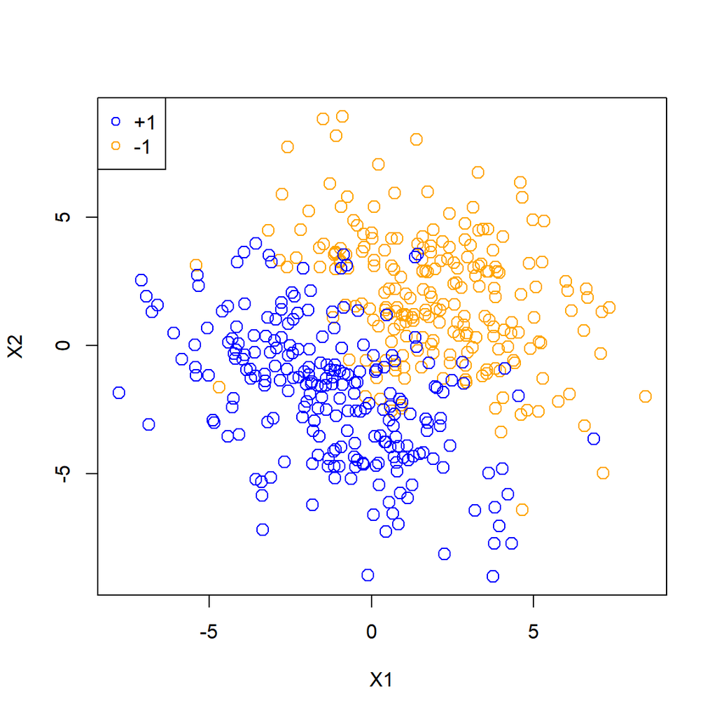

```r
data4 = read.csv("data4_train.csv")

orange = data4[data4$y == -1, ]
blue = data4[data4$y == 1, ]
plot(orange$x1, orange$x2, col = "orange",
     xlim = c(min(data4$x1), max(data4$x1)),
     ylim = c(min(data4$x2), max(data4$x2)),
     xlab = "X1", ylab = "X2", cex = 1.4)
points(blue$x1, blue$x2, col = "blue", cex = 1.4)
legend("topleft", legend = c("+1", "-1"), pch = c(1, 1),
       col = c("blue", "orange"))
```

data4 를 이용하여 예측 모형을 제시하시오. (시험 데이터를 통해 모형의 성능을 평가할 예정)

```r
set.seed(1)

# library and data
library(e1071)
str(data4)
```

```
## 'data.frame':    450 obs. of  3 variables:
##  $ x1: num  1.607 3.641 3.335 -0.227 0.886 ...
##  $ x2: num  2.193 0.993 2.303 3.849 0.821 ...
##  $ y : int  -1 -1 -1 -1 -1 -1 1 -1 -1 1 ...
```

```r
data4$y = as.factor(data4$y)

# search
tune.out = tune(svm, y~., data = data4, kernel = "linear",
                ranges=list(cost=c(0.1,1,10,100,1000),
                            gamma=c(0.5,1,2,3,4) ))
summary(tune.out)
```

```
##
## Parameter tuning of 'svm':
##
## - sampling method: 10-fold cross validation
##
## - best parameters:
##  cost gamma
##     1   0.5
##
## - best performance: 0.09333333
##
## - Detailed performance results:
##     cost gamma      error dispersion
## 1  1e-01   0.5 0.09777778 0.02999771
## 2  1e+00   0.5 0.09333333 0.03747885
## 3  1e+01   0.5 0.09333333 0.03747885
## 4  1e+02   0.5 0.09333333 0.03747885
## 5  1e+03   0.5 0.09333333 0.03747885
## 6  1e-01   1.0 0.09777778 0.02999771
## 7  1e+00   1.0 0.09333333 0.03747885
## 8  1e+01   1.0 0.09333333 0.03747885
## 9  1e+02   1.0 0.09333333 0.03747885
## 10 1e+03   1.0 0.09333333 0.03747885
## 11 1e-01   2.0 0.09777778 0.02999771
## 12 1e+00   2.0 0.09333333 0.03747885
## 13 1e+01   2.0 0.09333333 0.03747885
## 14 1e+02   2.0 0.09333333 0.03747885
## 15 1e+03   2.0 0.09333333 0.03747885
## 16 1e-01   3.0 0.09777778 0.02999771
## 17 1e+00   3.0 0.09333333 0.03747885
## 18 1e+01   3.0 0.09333333 0.03747885
## 19 1e+02   3.0 0.09333333 0.03747885
## 20 1e+03   3.0 0.09333333 0.03747885
## 21 1e-01   4.0 0.09777778 0.02999771
## 22 1e+00   4.0 0.09333333 0.03747885
## 23 1e+01   4.0 0.09333333 0.03747885
## 24 1e+02   4.0 0.09333333 0.03747885
## 25 1e+03   4.0 0.09333333 0.03747885
```

```r
# best: gamma = 0.5,  cost = 1
fit_svm = svm(y ~., data = data4, kernel = "linear", gamma = 0.5, cost = 1)
summary(fit_svm)
```

```
##
## Call:
## svm(formula = y ~ ., data = data4, kernel = "linear", gamma = 0.5,
##     cost = 1)
##
##
## Parameters:
##    SVM-Type:  C-classification
##  SVM-Kernel:  linear
##        cost:  1
##
## Number of Support Vectors:  110
##
##  ( 55 55 )
##
##
## Number of Classes:  2
##
## Levels:
##  -1 1
```

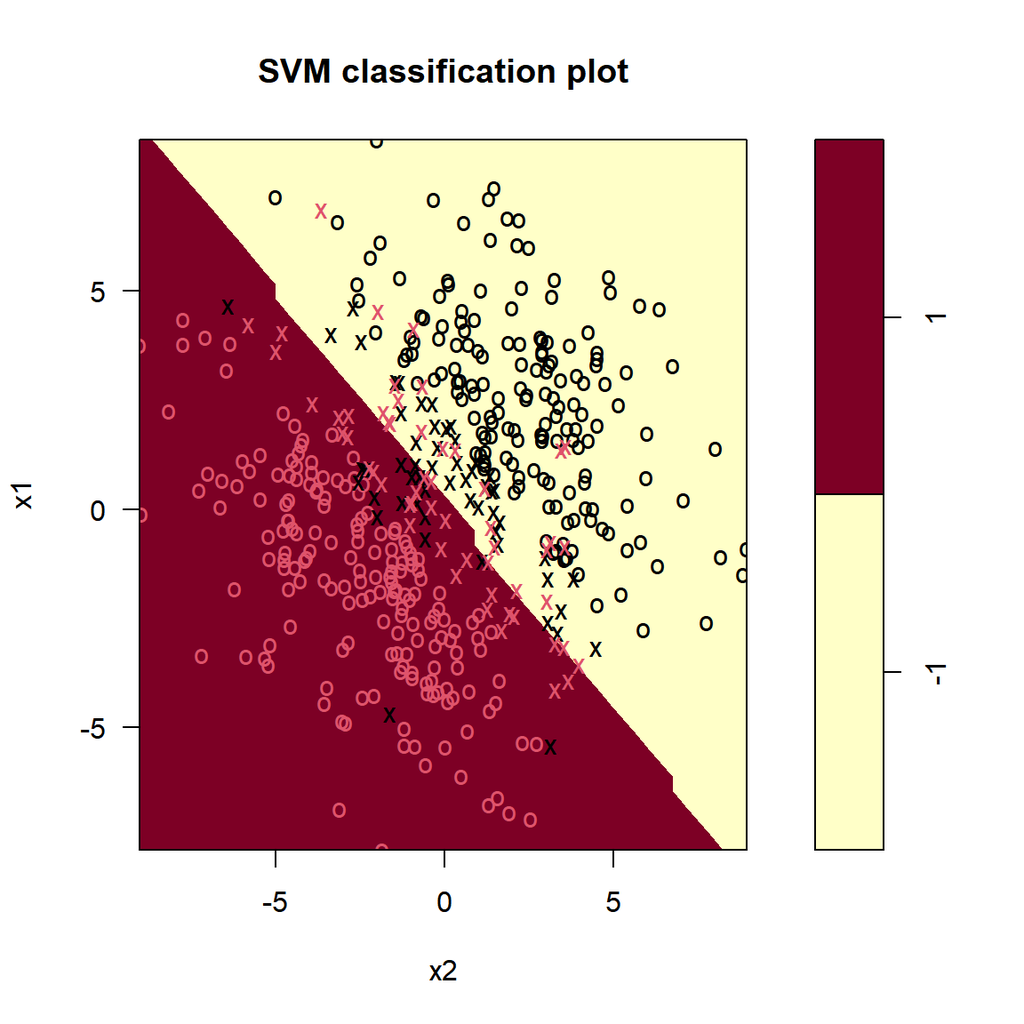

```r
plot(fit_svm, data4)
```

Performance 평가

```r
# pred = predict(fit_svm, test_X)
```

### Q5.

data5 는 두 개의 연속형 변수의 관측값들을 포함한다. $x$ 를 예측변수로, $y$ 를 반응변수로 하여 예측 모형을 만들고자 한다.

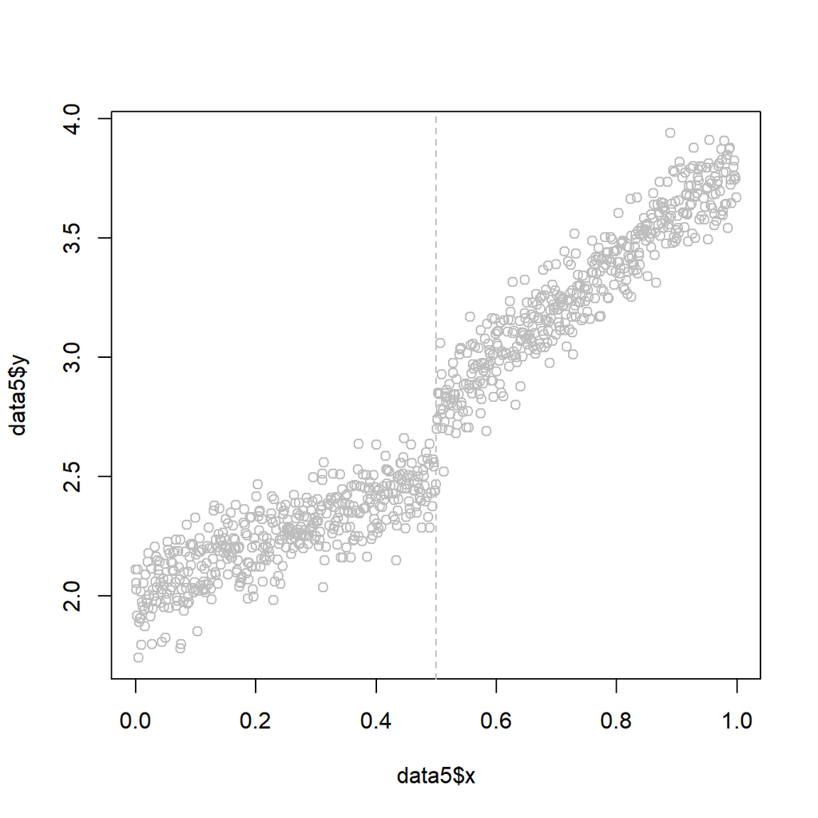

```r
data5 = read.csv("data5_train.csv")
plot(data5$x, data5$y, col = "grey")
abline(v = 0.5, lty = 2, col = "grey")
```

data5 를 이용하여 예측 모형을 제시하시오. (시험 데이터를 통해 모형의 성능을 평가할 예정)

```r
library(cobs)
knots = seq(0, 1, length = 100)
fit_spl = cobs(data5$x, data5$y, knots = knots, degree = 1)
```

```
## qbsks2():
##  Performing general knot selection ...
##
##  Deleting unnecessary knots ...
```

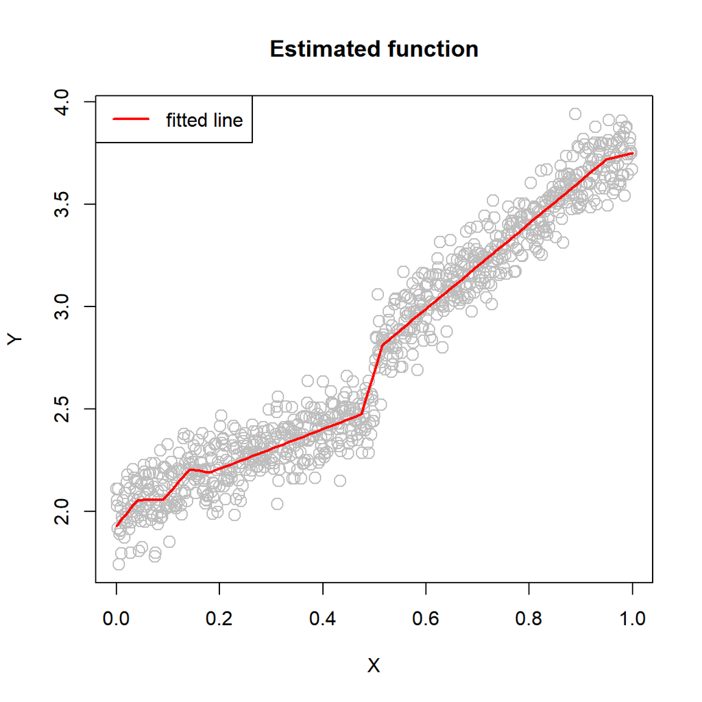

```r
plot(fit_spl, xlab = "X", ylab = "Y", main = "Estimated function", col = "grey",
     cex = 1.4)
legend("topleft", legend = c("fitted line"), lty = c(1),
       lwd = c(2), col = c("red"))
```

Performace 평가

```r
# pred = data.frame(predict(fit_spl, test_X))$fit
```